## Background

### Using devices such as Jawbone Up, Nike FuelBand, and Fitbit it is now possible to collect a large amount of data about personal activity relatively inexpensively. These type of devices are part of the quantified self movement – a group of enthusiasts who take measurements about themselves regularly to improve their health, to find patterns in their behavior, or because they are tech geeks. One thing that people regularly do is quantify how much of a particular activity they do, but they rarely quantify how well they do it.

### In this project, your goal will be to use data from accelerometers on the belt, forearm, arm, and dumbell of 6 participants. They were asked to perform barbell lifts correctly and incorrectly in 5 different ways. More information is available from the website here: http://groupware.les.inf.puc-rio.br/har (see the section on the Weight Lifting Exercise Dataset).

```r
library(caret)
```

```r
library(rpart)
library(rpart.plot)
library(RColorBrewer)
library(rattle)
library(randomForest)
library(corrplot)
library(gbm)
```

## Getting, Cleaning and Exploring the data

```r
traincsv <- read.csv("./data/pml-training.csv")
testcsv <- read.csv("./data/pml-testing.csv")
dim(traincsv)
```

```
## [1] 19622   160
```

```r
dim(testcsv)
```

```
## [1]  20 160
```

## Cleaning the Data

### Removing unnecessary variables. Starting with N/A variables.

```r
traincsv <- traincsv[,colMeans(is.na(traincsv)) < .9] #removing mostly na columns
traincsv <- traincsv[,-c(1:7)] #removing metadata which is irrelevant to the outcome
```

### Removing near zero variance variables.

```r
nvz <- nearZeroVar(traincsv)
traincsv <- traincsv[,-nvz]
dim(traincsv)
```

```
## [1] 19622    53
```

###Now that we have finished removing the unnecessary variables, we can now split the training set into a validation and sub training set. The testing set “testcsv” will be left alone, and used for the final quiz test cases.

```r
inTrain <- createDataPartition(y=traincsv$classe, p=0.7, list=F)
train <- traincsv[inTrain,]
valid <- traincsv[-inTrain,]
```

## Creating and Testing the Models

### Here we will test a few popular models including: Decision Trees, Random Forest, Gradient Boosted Trees, and SVM. This is probably more than we will need to test, but just out of curiosity and good practice we will run them for comparison.

### Set up control for training to use 3-fold cross validation.

```r
control <- trainControl(method="cv", number=3, verboseIter=F)
```

## Decision Tree

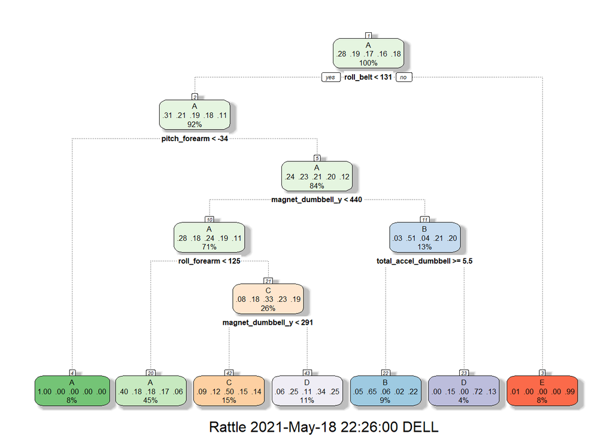

```r
mod_trees <- train(classe~., data=train, method="rpart", trControl = control, tuneLength = 5)
fancyRpartPlot(mod_trees$finalModel)
```

### Prediction

```r
pred_trees <- predict(mod_trees, valid)
cmtrees <- confusionMatrix(pred_trees, factor(valid$classe))
cmtrees
```

```
## Confusion Matrix and Statistics
##
##           Reference
## Prediction    A    B    C    D    E
##          A 1523  475  474  414  143
##          B   22  343   30   10  129
##          C   98  135  440  127  135
##          D   29  186   82  413  163
##          E    2    0    0    0  512
##
## Overall Statistics
##
##                Accuracy : 0.549
##                  95% CI : (0.5362, 0.5618)
##     No Information Rate : 0.2845
##     P-Value [Acc > NIR] : < 2.2e-16
##
##                   Kappa : 0.4128
##
##  Mcnemar's Test P-Value : < 2.2e-16
##
## Statistics by Class:
##
##                      Class: A Class: B Class: C Class: D Class: E
## Sensitivity            0.9098  0.30114  0.42885  0.42842  0.47320
## Specificity            0.6424  0.95976  0.89813  0.90652  0.99958
## Pos Pred Value         0.5028  0.64232  0.47059  0.47308  0.99611
## Neg Pred Value         0.9471  0.85124  0.88162  0.89006  0.89387
## Prevalence             0.2845  0.19354  0.17434  0.16381  0.18386
## Detection Rate         0.2588  0.05828  0.07477  0.07018  0.08700
## Detection Prevalence   0.5147  0.09074  0.15888  0.14834  0.08734
## Balanced Accuracy      0.7761  0.63045  0.66349  0.66747  0.73639
```

## Random Forest

```r
mod_rf <- train(classe~., data=train, method="rf", trControl = control, tuneLength = 5)

pred_rf <- predict(mod_rf, valid)
cmrf <- confusionMatrix(pred_rf, factor(valid$classe))
cmrf
```

```
## Confusion Matrix and Statistics
##
##           Reference
## Prediction    A    B    C    D    E
##          A 1671    6    0    0    0
##          B    2 1132    4    0    0
##          C    0    1 1021    6    1
##          D    0    0    1  958    6
##          E    1    0    0    0 1075
##
## Overall Statistics
##
##                Accuracy : 0.9952
##                  95% CI : (0.9931, 0.9968)
##     No Information Rate : 0.2845
##     P-Value [Acc > NIR] : < 2.2e-16
##
##                   Kappa : 0.994
##
##  Mcnemar's Test P-Value : NA
##
## Statistics by Class:
##
##                      Class: A Class: B Class: C Class: D Class: E
## Sensitivity            0.9982   0.9939   0.9951   0.9938   0.9935
## Specificity            0.9986   0.9987   0.9984   0.9986   0.9998
## Pos Pred Value         0.9964   0.9947   0.9922   0.9927   0.9991
## Neg Pred Value         0.9993   0.9985   0.9990   0.9988   0.9985
## Prevalence             0.2845   0.1935   0.1743   0.1638   0.1839
## Detection Rate         0.2839   0.1924   0.1735   0.1628   0.1827
## Detection Prevalence   0.2850   0.1934   0.1749   0.1640   0.1828
## Balanced Accuracy      0.9984   0.9963   0.9967   0.9962   0.9967
```

## Gradient Boosted Trees

```r
mod_gbm <- train(classe~., data=train, method="gbm", trControl = control, tuneLength = 5, verbose = F)

pred_gbm <- predict(mod_gbm, valid)
cmgbm <- confusionMatrix(pred_gbm, factor(valid$classe))
cmgbm
```

```
## Confusion Matrix and Statistics
##
##           Reference
## Prediction    A    B    C    D    E
##          A 1670    4    0    0    0
##          B    2 1131    3    0    0
##          C    1    4 1018    4    6
##          D    1    0    3  959    7
##          E    0    0    2    1 1069
##
## Overall Statistics
##
##                Accuracy : 0.9935
##                  95% CI : (0.9911, 0.9954)
##     No Information Rate : 0.2845
##     P-Value [Acc > NIR] : < 2.2e-16
##
##                   Kappa : 0.9918
##
##  Mcnemar's Test P-Value : NA
##
## Statistics by Class:
##
##                      Class: A Class: B Class: C Class: D Class: E
## Sensitivity            0.9976   0.9930   0.9922   0.9948   0.9880
## Specificity            0.9991   0.9989   0.9969   0.9978   0.9994
## Pos Pred Value         0.9976   0.9956   0.9855   0.9887   0.9972
## Neg Pred Value         0.9991   0.9983   0.9984   0.9990   0.9973
## Prevalence             0.2845   0.1935   0.1743   0.1638   0.1839
## Detection Rate         0.2838   0.1922   0.1730   0.1630   0.1816
## Detection Prevalence   0.2845   0.1930   0.1755   0.1648   0.1822
## Balanced Accuracy      0.9983   0.9960   0.9946   0.9963   0.9937
```

## Support Vector Machine

```r
mod_svm <- train(classe~., data=train, method="svmLinear", trControl = control, tuneLength = 5, verbose = F)

pred_svm <- predict(mod_svm, valid)
cmsvm <- confusionMatrix(pred_svm, factor(valid$classe))
cmsvm
```

```
## Confusion Matrix and Statistics
##
##           Reference
## Prediction    A    B    C    D    E
##          A 1550  155   79   63   57
##          B   33  799   92   41  128
##          C   39   67  805   96   65
##          D   45   28   27  724   62
##          E    7   90   23   40  770
##
## Overall Statistics
##
##                Accuracy : 0.7898
##                  95% CI : (0.7792, 0.8002)
##     No Information Rate : 0.2845
##     P-Value [Acc > NIR] : < 2.2e-16
##
##                   Kappa : 0.7328
##
##  Mcnemar's Test P-Value : < 2.2e-16
##
## Statistics by Class:
##
##                      Class: A Class: B Class: C Class: D Class: E
## Sensitivity            0.9259   0.7015   0.7846   0.7510   0.7116
## Specificity            0.9159   0.9381   0.9451   0.9671   0.9667
## Pos Pred Value         0.8141   0.7310   0.7509   0.8172   0.8280
## Neg Pred Value         0.9689   0.9290   0.9541   0.9520   0.9370
## Prevalence             0.2845   0.1935   0.1743   0.1638   0.1839
## Detection Rate         0.2634   0.1358   0.1368   0.1230   0.1308
## Detection Prevalence   0.3235   0.1857   0.1822   0.1506   0.1580
## Balanced Accuracy      0.9209   0.8198   0.8648   0.8591   0.8392
```

## Predictions on Test Set

### Running our test set to predict the classe (5 levels) outcome for 20 cases with the Random Forest model.

```r
pred <- predict(mod_rf, testcsv)
print(pred)
```

```
##  [1] B A B A A E D B A A B C B A E E A B B B
## Levels: A B C D E
```

## Appendix

### correlation matrix of variables in training set

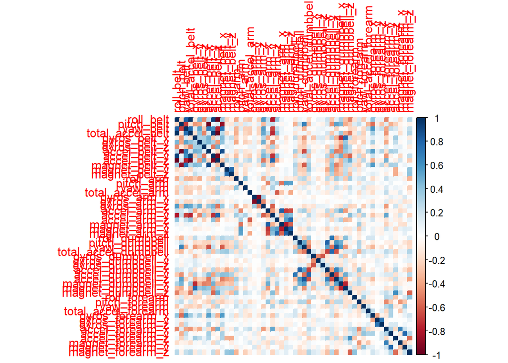

```r
corrPlot <- cor(train[, -length(names(train))])
corrplot(corrPlot, method="color")
```

### Plotting the models

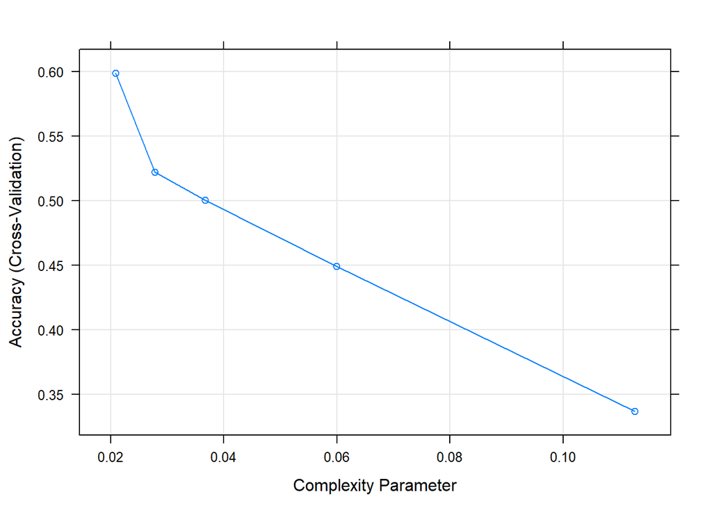

```r
plot(mod_trees)
```

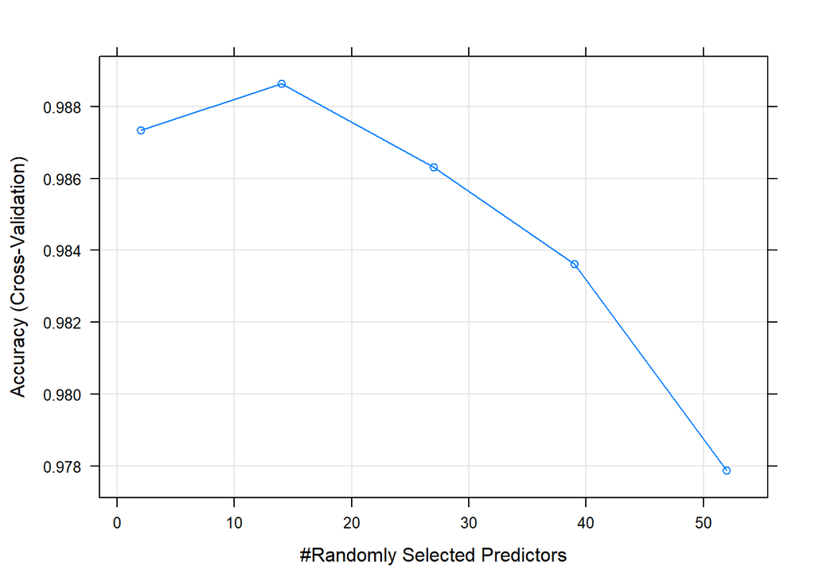

```r
plot(mod_rf)
```

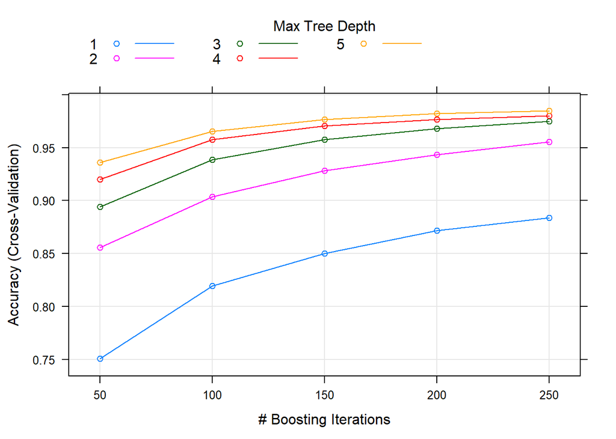

```r
plot(mod_gbm)
```